# Part I - ProsperLoanData

## Introduction

This is a Loan data set contains 113,937 loans with 81 variables on each loan, including loan amount, borrower rate (or interest rate), current loan status, borrower income, and many others.

```python
# import all packages and set plots to be embedded inline
import numpy as np
import pandas as pd
import matplotlib.pyplot as plt
import seaborn as sb

%matplotlib inline

# suppress warnings from final output
import warnings
warnings.simplefilter("ignore")
```

```python
# load the data
df = pd.read_csv('prosperLoanData.csv')
```

```python
# investigate the dataset
print(df.shape)
print(df.head())
print(df.info())
print(df.describe())
```

```
(113937, 81)
                ListingKey  ListingNumber            ListingCreationDate  \
0  1021339766868145413AB3B         193129  2007-08-26 19:09:29.263000000
1  10273602499503308B223C1        1209647  2014-02-27 08:28:07.900000000
2  0EE9337825851032864889A          81716  2007-01-05 15:00:47.090000000
3  0EF5356002482715299901A         658116  2012-10-22 11:02:35.010000000
4  0F023589499656230C5E3E2         909464  2013-09-14 18:38:39.097000000

  CreditGrade  Term LoanStatus           ClosedDate  BorrowerAPR  \
0           C    36  Completed  2009-08-14 00:00:00      0.16516
1         NaN    36    Current                  NaN      0.12016
2          HR    36  Completed  2009-12-17 00:00:00      0.28269
3         NaN    36    Current                  NaN      0.12528
4         NaN    36    Current                  NaN      0.24614

   BorrowerRate  LenderYield  ...  LP_ServiceFees  LP_CollectionFees  \
0        0.1580       0.1380  ...         -133.18                0.0
1        0.0920       0.0820  ...            0.00                0.0
2        0.2750       0.2400  ...          -24.20                0.0
3        0.0974       0.0874  ...         -108.01                0.0
4        0.2085       0.1985  ...          -60.27                0.0

   LP_GrossPrincipalLoss  LP_NetPrincipalLoss LP_NonPrincipalRecoverypayments  \
0                    0.0                  0.0                             0.0
1                    0.0                  0.0                             0.0
2                    0.0                  0.0                             0.0
3                    0.0                  0.0                             0.0
4                    0.0                  0.0                             0.0

   PercentFunded  Recommendations InvestmentFromFriendsCount  \
0            1.0                0                          0
1            1.0                0                          0
2            1.0                0                          0
3            1.0                0                          0
4            1.0                0                          0

  InvestmentFromFriendsAmount Investors
0                         0.0       258
1                         0.0         1
2                         0.0        41
```

[output cut: 139 more lines]

```
50%                           0.000000       1.000000         0.000000
75%                           0.000000       1.000000         0.000000
max                       21117.900000       1.012500        39.000000

       InvestmentFromFriendsCount  InvestmentFromFriendsAmount      Investors
count               113937.000000                113937.000000  113937.000000
mean                     0.023460                    16.550751      80.475228
std                      0.232412                   294.545422     103.239020
min                      0.000000                     0.000000       1.000000
25%                      0.000000                     0.000000       2.000000
50%                      0.000000                     0.000000      44.000000
75%                      0.000000                     0.000000     115.000000
max                     33.000000                 25000.000000    1189.000000

[8 rows x 61 columns]
```

### What is the structure of your dataset?

> The dataset has 113937 Rows and 81 columns 61 Columns are numeric

### What is/are the main feature(s) of interest in your dataset?

> 1. How character,capacity,conditions of credit analysis affect the credit score
> 2. How the cost of loan affect loan uptake
> 3. Factors that affect loan outcome status

### What features in the dataset do you think will help support your investigation into your feature(s) of interest?

- 3'C of credit Analysis

  > Character:LoanStatus  
  > Capacity:DebtToIncomeRatio, Income Range, LoanOriginalAmount, StatedMonthlyIncome  
  > Conditions:Occupation, EmploymentStatus, EmploymentStatusDuration,Term
- Cost of loan

  > BorrowerAPR, BorrowerRate,Lenders Yield
- Delinquencies

  > CurrentDelinquencies, AmountDelinquent, DelinquenciesLast7Years
- Lisings

  > ListingCategory, PercentFunded, Investors, Recommendations, EstimatedReturn

## Preliminary Wrangling

```python
df["LoanOriginationDate"].value_counts()
```

```
2014-01-22 00:00:00    491
2013-11-13 00:00:00    490
2014-02-19 00:00:00    439
2013-10-16 00:00:00    434
2014-01-28 00:00:00    339
                      ...
2006-02-03 00:00:00      1
2006-01-24 00:00:00      1
2005-11-18 00:00:00      1
2009-07-20 00:00:00      1
2005-11-15 00:00:00      1
Name: LoanOriginationDate, Length: 1873, dtype: int64
```

```python
# Subset the dataset to have columns of intrest and save to a new dataframe df_loans
columns= ['Term','LoanStatus','BorrowerAPR','BorrowerRate','LenderYield','EstimatedReturn','ProsperRating (numeric)',
          'ProsperRating (Alpha)','ProsperScore','Occupation','EmploymentStatus','IsBorrowerHomeowner',
         'AmountDelinquent','DelinquenciesLast7Years','DebtToIncomeRatio','IncomeRange','IncomeVerifiable',
          'StatedMonthlyIncome','TotalProsperLoans','LoanOriginalAmount','LoanOriginationDate','MonthlyLoanPayment','PercentFunded','Investors','ListingCategory (numeric)']
df_loans=df[columns]
df_loans.info()
```

```
<class 'pandas.core.frame.DataFrame'>
RangeIndex: 113937 entries, 0 to 113936
Data columns (total 25 columns):
 #   Column                     Non-Null Count   Dtype
---  ------                     --------------   -----
 0   Term                       113937 non-null  int64
 1   LoanStatus                 113937 non-null  object
 2   BorrowerAPR                113912 non-null  float64
 3   BorrowerRate               113937 non-null  float64
 4   LenderYield                113937 non-null  float64
 5   EstimatedReturn            84853 non-null   float64
 6   ProsperRating (numeric)    84853 non-null   float64
 7   ProsperRating (Alpha)      84853 non-null   object
 8   ProsperScore               84853 non-null   float64
 9   Occupation                 110349 non-null  object
```

[output cut: 17 more lines]

```python
# Select dataset with date from 2009
df_loans = df_loans[df_loans['LoanOriginationDate']>='2009-01-01 00:00:00']

print(df_loans['LoanOriginationDate'].value_counts())
```

```
2014-01-22 00:00:00    491
2013-11-13 00:00:00    490
2014-02-19 00:00:00    439
2013-10-16 00:00:00    434
2014-01-28 00:00:00    339
                      ...
2010-03-02 00:00:00      2
2009-07-20 00:00:00      1
2009-07-28 00:00:00      1
2009-07-24 00:00:00      1
2009-07-23 00:00:00      1
Name: LoanOriginationDate, Length: 1171, dtype: int64
```

```python
# find duplicates
df_loans.columns.duplicated().sum()
```

```
0
```

```python
# find nulls
df_loans.isnull().sum()
```

```
Term                             0
LoanStatus                       0
BorrowerAPR                      0
BorrowerRate                     0
LenderYield                      0
EstimatedReturn                144
ProsperRating (numeric)        144
ProsperRating (Alpha)          144
ProsperScore                   144
Occupation                    1333
EmploymentStatus                 0
IsBorrowerHomeowner              0
AmountDelinquent                 0
DelinquenciesLast7Years          0
DebtToIncomeRatio             7307
IncomeRange                      0
IncomeVerifiable                 0
StatedMonthlyIncome              0
TotalProsperLoans            65130
LoanOriginalAmount               0
LoanOriginationDate              0
MonthlyLoanPayment               0
PercentFunded                    0
Investors                        0
ListingCategory (numeric)        0
dtype: int64
```

```python
#convert datatype to category for all categorical columns
df_loans['Occupation'] = df_loans['Occupation'].astype('category')
df_loans['LoanStatus'] = df_loans['LoanStatus'].astype('category')
df_loans['ListingCategory (numeric)'] = df_loans['ListingCategory (numeric)'].astype('category')
df_loans['EmploymentStatus'] = df_loans['EmploymentStatus'].astype('category')
df_loans['IncomeRange'] = df_loans['IncomeRange'].astype('category')
df_loans['ProsperRating (Alpha)'] = df_loans['ProsperRating (Alpha)'].astype('category')
df_loans['ProsperRating (numeric)'] = df_loans['ProsperRating (numeric)'].astype('category')
#convert datatype to datetime for all date columns
df_loans['LoanOriginationDate'] = pd.to_datetime(df_loans['LoanOriginationDate'])
df_loans.info()
```

```
<class 'pandas.core.frame.DataFrame'>
Int64Index: 84997 entries, 1 to 113936
Data columns (total 25 columns):
 #   Column                     Non-Null Count  Dtype
---  ------                     --------------  -----
 0   Term                       84997 non-null  int64
 1   LoanStatus                 84997 non-null  category
 2   BorrowerAPR                84997 non-null  float64
 3   BorrowerRate               84997 non-null  float64
 4   LenderYield                84997 non-null  float64
 5   EstimatedReturn            84853 non-null  float64
 6   ProsperRating (numeric)    84853 non-null  category
 7   ProsperRating (Alpha)      84853 non-null  category
 8   ProsperScore               84853 non-null  float64
 9   Occupation                 83664 non-null  category
```

[output cut: 17 more lines]

## Univariate Exploration

> In this section, I have investigate distributions of individual variables.

#### Question

> What is the distribution of loans based on status

#### Visualization

```python
# create loanstatus series and find value counts
ls = df_loans['LoanStatus']
# all values of 'past due' to have same name
vals = ['Past Due (1-15 days)','Past Due (16-30 days)','Past Due (31-60 days)','Past Due (61-90 days)',
         'Past Due (91-120 days)','Past Due (>120 days)','Past Due (1-15 days)']
ls.replace(vals , 'PastDue', inplace = True)
ls.value_counts().sort_index()
```

```
Chargedoff                 5344
Completed                 19796
Current                   56576
Defaulted                  1009
FinalPaymentInProgress      205
PastDue                    2067
Name: LoanStatus, dtype: int64
```

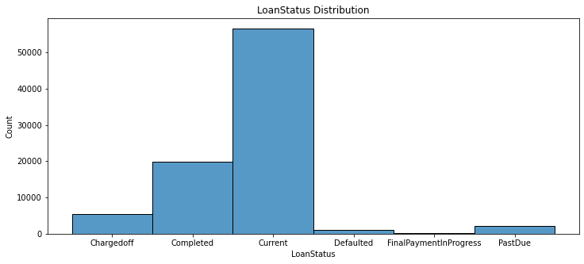

```python
plt.figure(figsize=(12,5))
sb.histplot(data=df_loans,x='LoanStatus').set(title='LoanStatus Distribution');
```

#### Observations

> From the LoanStatus Distribution most loans are either in current or completed status. Most loans are performing loans with few non performing loans.

#### Question

> what is the most ideal DebtToIncome ratio for a loan to be granted?

#### Visualization

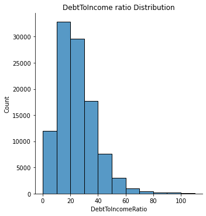

```python
di= df.DebtToIncomeRatio*100
sb.displot(data = df_loans, x= di, bins=[0,10, 20, 30, 40, 50, 60, 70,80,90,100,110]).set(title='DebtToIncome ratio Distribution');
```

#### Observation

> DebtToIncome ratio is mostly scattered within the range 10% - 40%. This means that most loans are granted when the DebtToIncome ratio is within the same range

#### Question

> what is the most ideal IncomeRange for a loan to be granted?

#### Visualization

```python
print(df_loans['IncomeRange'].value_counts())
```

```
$50,000-74,999    25675
$25,000-49,999    24221
$100,000+         15223
$75,000-99,999    14515
$1-24,999          4669
Not employed        649
$0                   45
Name: IncomeRange, dtype: int64
```

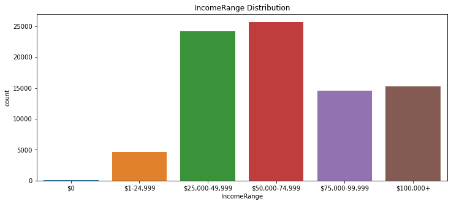

```python
income_range_order =['$0','$1-24,999','$25,000-49,999','$50,000-74,999','$75,000-99,999','$100,000+']
plt.figure(figsize=(12,5))
sb.countplot(data=df_loans,x='IncomeRange', order=income_range_order).set(title='IncomeRange Distribution');
```

#### Observation

> Most loans borrowers have an income range of 25k-75K  
> The lower the income range few loans are granted

#### Question

> What is the distribution of ListingCategory?

#### Visualization

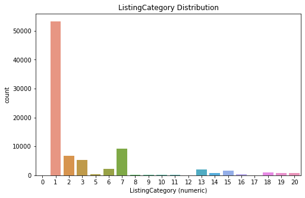

```python
plt.figure(figsize=(8,5))
sb.countplot(data=df_loans,x='ListingCategory (numeric)').set(title='ListingCategory Distribution');
```

#### Observation

> The most considered listing category is Debt Consolidation, followed by other, home improvement and business

#### Question

> what is the distribution of Occupation?

```python
# find and catagorize the occupations
pd.set_option('display.max_rows', 500)
df_loans['Occupation'].value_counts()
values = ['Computer Programmer','Executive','Teacher','Administrative Assistant','Analyst','Sales - Commission','Accountant/CPA',
         'Clerical','Sales - Retail','Skilled Labor','Retail Management','Nurse (RN)','Construction','Truck Driver','Laborer',
         'Police Officer/Correction Officer','Civil Service','Engineer - Mechanical','Military Enlisted','Food Service Management',
         'Engineer - Electrical','Food Service Management','Medical Technician','Attorney','Social Worker','Postal Service','Professor',
        'Realtor','Doctor','Nurse (LPN)',"Nurse's Aide",'Waiter/Waitress','Fireman','Scientist','Military Officer','Bus Driver',
          'Principal',"Teacher's Aide",'Pharmacist','Landscaping','Engineer – Chemical','Investor','Pilot - Private/Commercial',
          'Clergy','Car Dealer','Chemist’,‘Psychologist','Biologist','Religious','Flight Attendant','Homemaker','Dentist',
         'Judge','Food Service','Engineer - Chemical','Architect','Chemist','Psychologist','Tradesman - Carpenter',
          'Tradesman - Plumber','Tradesman - Plumber', 'Tradesman - Mechanic','Tradesman - Electrician']
student = ['Student - College Graduate Student','Student - College Senior','Student - College Sophomore','Student - College Junior',
           'Student - College Freshman','Student - Community College', 'Student - Technical School']
df_loans.replace(values,'Professional',inplace = True)
df_loans.replace(student,'Student',inplace = True)


df_loans['Occupation'].value_counts()
```

```
Professional    62059
Other           21348
Student           257
Name: Occupation, dtype: int64
```

#### Visualization

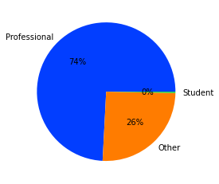

```python
data=[62059,21348,257]
keys = ['Professional', 'Other', 'Student']

# define Seaborn color palette to use
palette_color = sb.color_palette('bright')

# plotting data on chart
plt.pie(data, labels=keys, colors=palette_color, autopct='%.0f%%');
```

#### Observation

> Most loans are being held by professionals at 74% with others as 26% and students less than 1%

#### Question

> What employment status is most ideal for loan to be granted?

#### Visualization

```
[Text(0.5, 1.0, 'EmploymentStatus Distribution')]
```

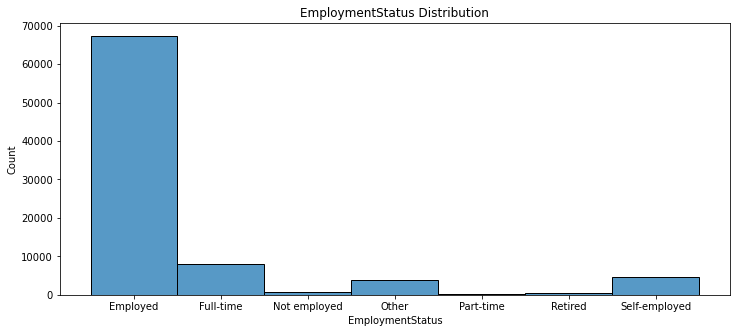

```python
plt.figure(figsize=(12,5))
sb.histplot(data=df_loans,x='EmploymentStatus').set(title='EmploymentStatus Distribution')
```

#### Observation

> The most ideal employment status considered for loan to be granteed is being 'employed' and 'full term'  
> 'Not employed','part time' and 'retired' are either not given loans or they are unlikely to apply for a loan

#### Question

> What is the distribution of LoanOriginalAmount?

```python
print(df_loans['LoanOriginalAmount'].describe())
print(df_loans['LoanOriginalAmount'].info())
```

```
count    84997.000000
mean      9074.835877
std       6287.295868
min       1000.000000
25%       4000.000000
50%       7500.000000
75%      13500.000000
max      35000.000000
Name: LoanOriginalAmount, dtype: float64
<class 'pandas.core.series.Series'>
Int64Index: 84997 entries, 1 to 113936
Series name: LoanOriginalAmount
Non-Null Count  Dtype
--------------  -----
84997 non-null  int64
dtypes: int64(1)
memory usage: 3.3 MB
None
```

#### Visualization

```
[Text(0.5, 1.0, 'LoanOriginalAmount Distribution')]
```

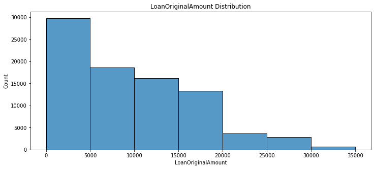

```python
plt.figure(figsize=(12,5))
sb.histplot(data=df_loans,x='LoanOriginalAmount', bins=[0,5000,10000,15000,20000,25000,30000,35000]).set(title='LoanOriginalAmount Distribution')
```

#### Observations

> The distribution is right skewed with Most members having OriginalLoanAmount less than 5000. As the orginalLoanAmount increases less people qualify for higher Loan amounts

#### Question

> What is the distribution of the Terms?

#### Vizualisation

```python
df_loans['Term'].value_counts()
```

```
36    58838
60    24545
12     1614
Name: Term, dtype: int64
```

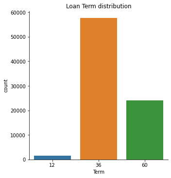

```python
sb.catplot(x ='Term', data = df_loans, kind ='count').set(title ='Loan Term distribution');
```

#### Question BorrowerRate

> What is the distribution of BorrowerAPR?

#### Visualization

```python
print(df_loans['BorrowerAPR'].value_counts())
print(df_loans['BorrowerAPR'].describe())
```

```
0.35797    3672
0.35643    1644
0.30532     902
0.29510     747
0.35356     721
           ...
0.18477       1
0.29961       1
0.31400       1
0.11003       1
0.22674       1
Name: BorrowerAPR, Length: 2361, dtype: int64
count    84997.000000
mean         0.226595
std          0.079949
min          0.045830
25%          0.163240
50%          0.219450
75%          0.292540
max          0.423950
Name: BorrowerAPR, dtype: float64
```

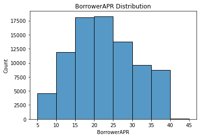

```python
arp=df_loans['BorrowerAPR']*100
sb.histplot(data=df_loans,x=arp, bins= [5,10,15,20,25,30,35,40,45]).set(title='BorrowerAPR Distribution');
```

#### Observation

> The distribution of BorrowerARP is normally disitributed with it peak between 15% and 20%

#### Question

> what is th distribution of BorrowerRate?

#### Visualization

```python
df_loans['BorrowerRate'].describe()
```

```
count    84997.000000
mean         0.195968
std          0.074659
min          0.040000
25%          0.135900
50%          0.187500
75%          0.257400
max          0.360000
Name: BorrowerRate, dtype: float64
```

```
[Text(0.5, 1.0, 'BorrowerRate Distribution')]
```

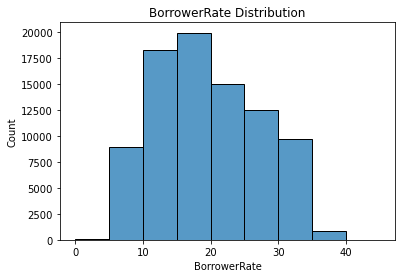

```python
r = df_loans['BorrowerRate']*100
sb.histplot(data=df,x=r,bins= [0,5,10,15,20,25,30,35,40,45]).set(title='BorrowerRate Distribution')
```

#### Question

> What is the distribution of Prosper rating (Alpha)?

```python
print(df_loans['ProsperRating (numeric)'].describe())
print(df_loans['ProsperRating (numeric)'].value_counts())
print(df_loans['ProsperRating (Alpha)'].describe())
print(df_loans['ProsperRating (Alpha)'].value_counts())
```

```
count     84853.0
unique        7.0
top           4.0
freq      18345.0
Name: ProsperRating (numeric), dtype: float64
4.0    18345
5.0    15581
6.0    14551
3.0    14274
2.0     9795
1.0     6935
7.0     5372
Name: ProsperRating (numeric), dtype: int64
count     84853
unique        7
top           C
freq      18345
Name: ProsperRating (Alpha), dtype: object
C     18345
B     15581
A     14551
D     14274
E      9795
HR     6935
AA     5372
Name: ProsperRating (Alpha), dtype: int64
```

#### Visualization

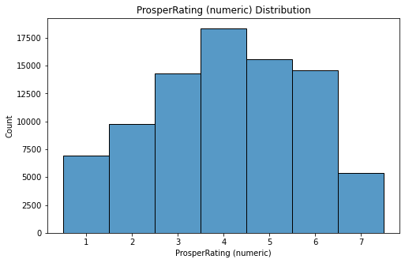

```python
plt.figure(figsize=(8,5))
sb.histplot(data=df_loans,x='ProsperRating (numeric)').set(title='ProsperRating (numeric) Distribution');
```

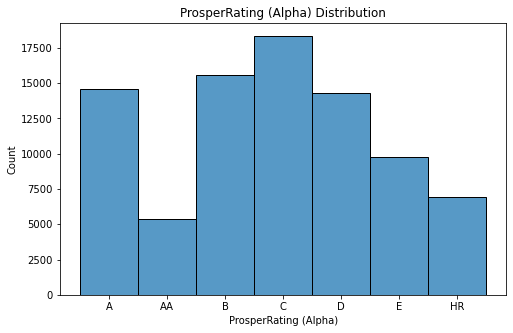

```python
plt.figure(figsize=(8,5))
sb.histplot(data=df_loans,x='ProsperRating (Alpha)').set(title='ProsperRating (Alpha) Distribution');
```

#### Observation

> Most popular ProsperRating (Alpha) is between A,B,C,D while AA,HR and E are least popular  
> ProsperRating (numeric) is normally distribution, with its peak at 4 The Prosper Rating 0 - N/A, 1 - HR, 2 - E, 3 - D, 4 - C, 5 - B, 6 - A, 7 - AA. Applicable for loans originated after July 2009.

#### Question

What is the distribution of prosperScore?

#### Visualization

```python
print(df_loans['ProsperScore'].describe())
print(df_loans['ProsperScore'].value_counts())
```

```
count    84853.000000
mean         5.950067
std          2.376501
min          1.000000
25%          4.000000
50%          6.000000
75%          8.000000
max         11.000000
Name: ProsperScore, dtype: float64
4.0     12595
6.0     12278
8.0     12053
7.0     10597
5.0      9813
3.0      7642
9.0      6911
2.0      5766
10.0     4750
11.0     1456
1.0       992
Name: ProsperScore, dtype: int64
```

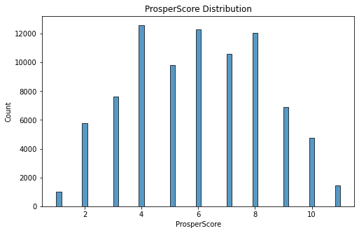

```python
plt.figure(figsize=(8,5))
sb.histplot(data=df_loans,x='ProsperScore').set(title='ProsperScore Distribution');
```

```python
print(df_loans['ProsperScore'].isnull().sum())
print((df_loans['ProsperScore'] > 10).sum())
```

```
144
1456
```

```python
df_loans.dropna(subset=['ProsperScore'], how='all', inplace=True)
print(df_loans['ProsperScore'].isnull().sum())
```

```
0
```

```python
df_loans = df_loans[df_loans['ProsperScore'] <= 10]
print(df_loans['ProsperScore'].value_counts())
```

```
4.0     12595
6.0     12278
8.0     12053
7.0     10597
5.0      9813
3.0      7642
9.0      6911
2.0      5766
10.0     4750
1.0       992
Name: ProsperScore, dtype: int64
```

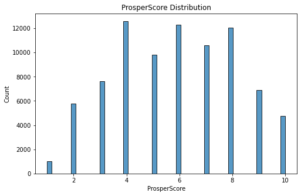

```python
plt.figure(figsize=(8,5))
sb.histplot(data=df_loans,x='ProsperScore').set(title='ProsperScore Distribution');
```

#### Observations

> Most loans have a Prosper score of 4,6,8

#### Question

> What is the Investors distrbution

#### Visualization

```python
print(df_loans['Investors'].describe())
print(df_loans['Investors'].value_counts())
```

```
count    83397.000000
mean        67.810161
std         94.190355
min          1.000000
25%          1.000000
50%         32.000000
75%         96.000000
max       1189.000000
Name: Investors, dtype: float64
1      26609
2       1199
3        868
4        695
8        613
       ...
679        1
586        1
610        1
774        1
618        1
Name: Investors, Length: 677, dtype: int64
```

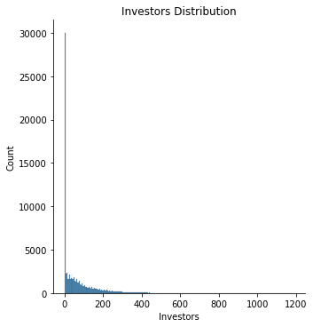

```python
plt.figure(figsize=(8,5))
sb.displot(data=df_loans,x='Investors').set(title='Investors Distribution');
```

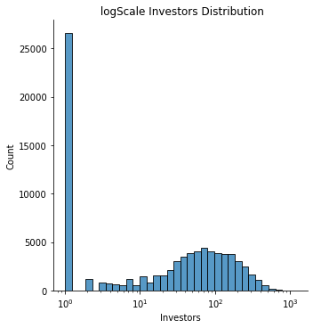

```python
plt.figure(figsize=(8,5))
sb.displot(data=df_loans,x='Investors',log_scale=True).set(title=' logScale Investors Distribution');
```

#### Observations

> Most loan listings have 1 investor. apart from 1,the other graph is normally distributed.

#### Question

> what is the EstimatedReturn distribution?

#### Visualization

```python
print(df_loans['EstimatedReturn'].value_counts())
print(df_loans['EstimatedReturn'].describe())
```

```
0.1246    2217
0.1487    1097
0.0691     746
0.1414     738
0.1074     654
          ...
0.0298       1
0.1198       1
0.1951       1
0.0439       1
0.1847       1
Name: EstimatedReturn, Length: 1476, dtype: int64
count    83397.000000
mean         0.096764
std          0.030163
min         -0.182700
25%          0.074900
50%          0.092600
75%          0.117300
max          0.283700
Name: EstimatedReturn, dtype: float64
```

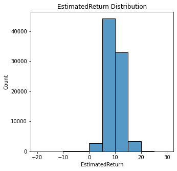

```python
plt.figure(figsize=(5,5))
er = df_loans['EstimatedReturn']*100
sb.histplot(data=df_loans,x=er,bins=[-20,-10,0,5,10,15,20,25,30]).set(title='EstimatedReturn Distribution');
```

#### Observation

> the graph is a normal distribution. The most ideal EstimatedReturn range is 5 to 15%

### Of the features you investigated, were there any unusual distributions? Did you perform any operations on the data to tidy, adjust, or change the form of the data? If so, why did you do this?

> ProsperScore had erroneous score of 11 as the maximum is score should be 10. I dropped all the null values and values greater than the maximum score of 10

## Bivariate Exploration

> In this section, investigate relationships between pairs of variables in your data. Make sure the variables that you cover here have been introduced in some fashion in the previous section (univariate exploration).

#### Question

> What are the correlation betweeen Quantitative variables?

#### Visualization

```python
Quantitative_variables = ['Term', 'BorrowerAPR', 'BorrowerRate', 'LenderYield', 'ProsperScore',
                     'StatedMonthlyIncome', 'LoanOriginalAmount', 'MonthlyLoanPayment','Investors','AmountDelinquent','LoanCurrentDaysDelinquent',
                     'DebtToIncomeRatio','EstimatedReturn','Recommendations']
```

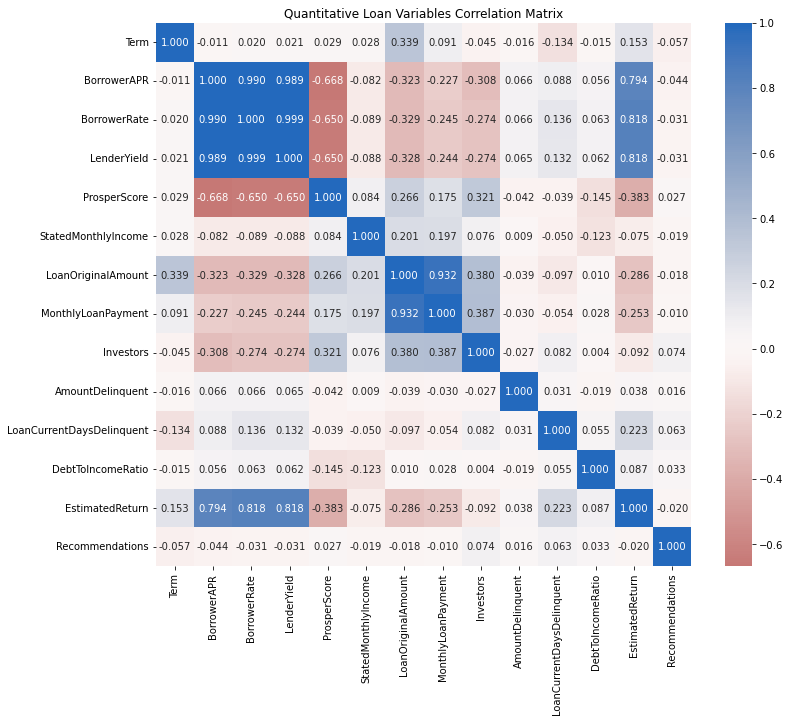

```python
plt.figure(figsize = [12,10])
sb.heatmap(df[Quantitative_variables].corr(), annot=True, fmt='.3f',cmap='vlag_r',center=0).set(title='Quantitative Loan Variables Correlation Matrix');
```

#### Observation

> There is a positive correlation between EstimatedReturn,BorrowerAPR,BorrowerRate and LenderYield  
> ProsperScore has a negative correlation with EstimatedReturn,DebtToIncomrRatio,BorrowerAPR,BorrowerRate and LenderYield. and Positive Correlation to Investors, MothlyLoanPayment, LoanOriginalAmount Investors have a positive correlation with MothlyLoanPayment, LoanOriginalAmount and ProsperScore

#### Question

What is the relationship between IncomeRange and LoanStatus?

#### Visualization

```python
df_loans['LoanStatus'].value_counts()
```

```
Current                   55157
Completed                 19633
Chargedoff                 5336
PastDue                    2065
Defaulted                  1004
FinalPaymentInProgress      202
Name: LoanStatus, dtype: int64
```

```python
# Categorize loans into goodloans and badloans types
# create list for goodloans
goodLoans = ['Current','Completed','FinalPaymentInProgress']
```

```python
# function to check loan type
def find_loan_type(LoanStatus):
    if LoanStatus in goodLoans:
        return 'GoodLoan'
    else:
        return 'BadLoan'

df_loans['LoanType'] = df_loans['LoanStatus'].apply(find_loan_type)
```

```python
df_loans['LoanType'].value_counts()
```

```
GoodLoan    74992
BadLoan      8405
Name: LoanType, dtype: int64
```

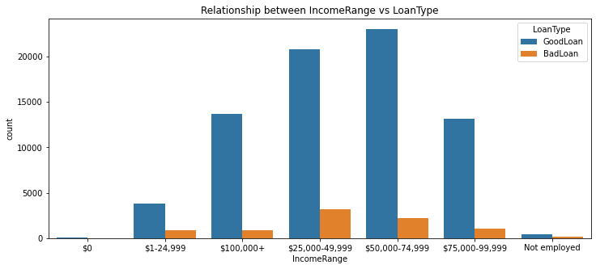

```python
plt.figure(figsize=[12, 5])
sb.countplot(data=df_loans,x='IncomeRange',hue='LoanType').set(title='Relationship between IncomeRange vs LoanType');
```

#### Question

> What is the relationship between LoanStatus VS ProsperScore

#### Visualization

[figure not shown]

```python
base_color = sb.color_palette()[0]
plt.figure(figsize=[12, 5])
sb.boxplot(data=df_loans,x='LoanStatus',y='ProsperScore', color= base_color).set(title='Relationship between LoanStatus vs ProsperScore');
```

#### Observation

> Current,Defaulted, FinalPaymentInProgress loan statuses have the same prosper rating of 6 Completed Loans have the highest Prosper Rating of 7 PastDue and ChargedOff loan status have a lower prosper rating of 5

#### Question

> What is the relationship between LoanType and BorrowerRate

#### Visualization

```python
base_color = sb.color_palette()[0]
```

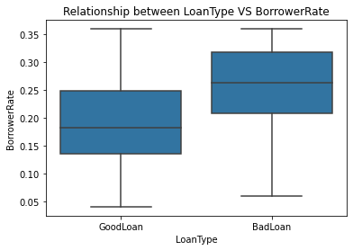

```python
sb.boxplot(data=df_loans,x='LoanType',y='BorrowerRate', color= base_color).set(title='Relationship between LoanType VS BorrowerRate');
```

#### Observations

> BadLoans have a higher BorrowerRate than GoodLoans

#### Question

> What is the relationship between BorrowerAPR and EmploymentStatus?

#### Visualization

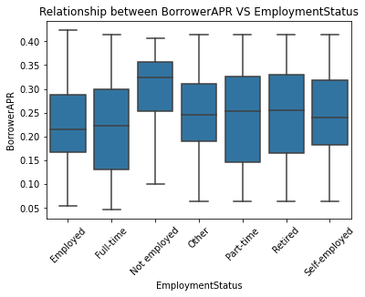

```python
sb.boxplot(data=df_loans,y='BorrowerAPR',x='EmploymentStatus',color=base_color).set(title='Relationship between BorrowerAPR VS EmploymentStatus');
plt.xticks(rotation='45');
```

#### Observations

> BorrowerAPR is the highest where employment status is not employed  
> Those employed have a lower borrower rate

#### Question

> What is the relationship between ProsperRating and IncomeRange?

#### Visualization

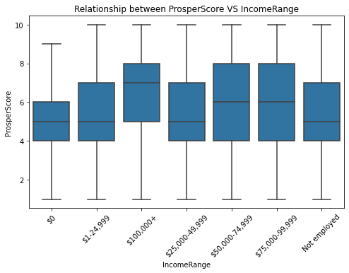

```python
plt.figure(figsize=[8, 5])
sb.boxplot(data=df_loans,y='ProsperScore',x='IncomeRange',color=base_color).set(title='Relationship between ProsperScore VS IncomeRange');
plt.xticks(rotation='45');
```

#### Observations

> Prosper score is higher at 7 when income range is highest(100,000+). with low Prosper score of 5 where income is less than 50,000

### Talk about some of the relationships you observed in this part of the investigation. How did the feature(s) of interest vary with other features in the dataset?

> ProseperScore has a negative correlation with EstimatedReturn, BorrowerAPR, BorrowerRate and LenderYield  
> Prosper score is higher at 7 when income range is highest(100,000+). With low Prosper score of 5 where income is less than 50,000

### Did you observe any interesting relationships between the other features (not the main feature(s) of interest)?

> Loan status thats are still inprogress such as Current,Defaulted, FinalPaymentInProgress have the same prosper rating of 6.

## Multivariate Exploration

> Create plots of three or more variables to investigate your data even further. Make sure that your investigations are justified, and follow from your work in the previous sections.

#### Question

> What is the relationship between LoanStatus Vs BorrowerAPR in each EmploymentStatus

#### Visualization

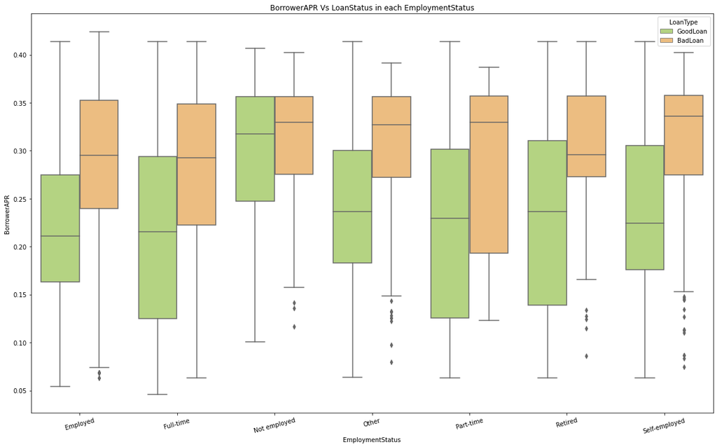

```python
# LoanStatus Vs BorrowerAPR in each EmploymentStatus
plt.figure(figsize=[20,12])
sb.boxplot(x="EmploymentStatus", y="BorrowerAPR", hue="LoanType", data=df_loans, palette="RdYlGn_r");
plt.title('BorrowerAPR Vs LoanStatus in each EmploymentStatus');
plt.xlabel('EmploymentStatus');
plt.ylabel('BorrowerAPR');
plt.xticks(rotation = 15);
```

#### Observations

> All badLoans have a higher BorrowerAPR across all Employment status categories. The EmploymentStatus, Not-employed has the highest BorrowerAPR

#### Question

> what is the relationship between IncomeRange, LoanOriginalAmount and Term

#### Visualization

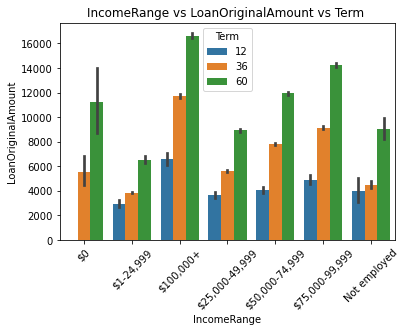

```python
sb.barplot(x = 'IncomeRange', y = 'LoanOriginalAmount', data = df_loans, hue='Term'). set(title ='IncomeRange vs LoanOriginalAmount vs Term ')
plt.xticks(rotation='45');
```

#### Observations

> The higher the LoanOriginalAmount the higher the Term in all IncomeRanges. Long term loans are more where income range is higher and loan amount increases

#### Question

> What is the relationship between DebtToIncomeRatio variable and ProsperRating variable in terms of LoanType

#### Visualization

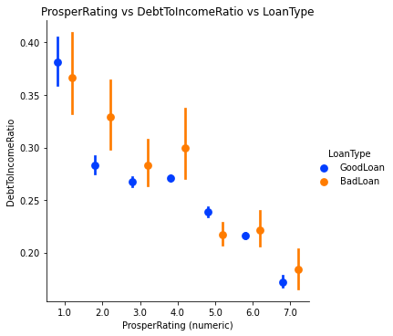

```python
sb.catplot(x='ProsperRating (numeric)', y='DebtToIncomeRatio', data=df_loans, palette='bright',kind='point',
           hue='LoanType',linestyles = '',dodge = 0.4). set(title='ProsperRating vs DebtToIncomeRatio vs LoanType');
```

#### Observation

> The higher the prosper rating the Lower the DebtToIncome ratio

#### Question

> what is the relationship between ProsperRating and BorrowerRate in terms of LoanType?

#### Visualization

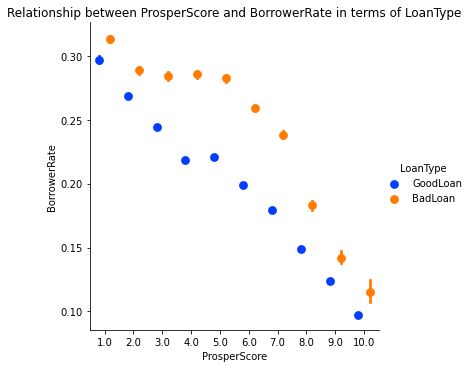

```python
sb.catplot(x='ProsperScore', y='BorrowerRate', data=df_loans, palette='bright',kind='point',hue='LoanType',
           linestyles = '',dodge = 0.4). set(title='Relationship between ProsperScore and BorrowerRate in terms of LoanType');
```

#### Observation

> The Better or higher the prosper Score yields lower Borrower rates.  
> on all prosper Score categories the bad loans have a higher Borrower rate

#### Question

> What is the relationship between LoanOriginalAmount,MonthlyLoanPayment and Term

#### Visualization

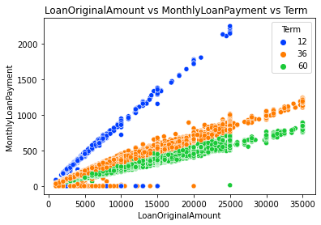

```python
sb.scatterplot(x='LoanOriginalAmount',y='MonthlyLoanPayment',data=df_loans,palette='bright',
    hue='Term'). set(title='LoanOriginalAmount vs MonthlyLoanPayment vs Term ');
```

#### Observation

> As the Term period decreases the Monthly Loan Payment Variable Increases. As the LoanOriginalAmount increases the Term period increases

### Talk about some of the relationships you observed in this part of the investigation. Were there features that strengthened each other in terms of looking at your feature(s) of interest?

> When the incomeRange(capacity) is higher and emplymentStatus(condition) is employed and fulltime the better the prosper score and the lower the cost of loan(BorrowerAPR and BorrowerRate)

### Were there any interesting or surprising interactions between features?

> When the credit risk score(prosperScore) is higher(less risky) the borrower rate is lower. This loans are mostly performing loans

## Conclusions

> You can write a summary of the main findings and reflect on the steps taken during the data exploration.

### Summary of the main findings

> i. ProsperScore has a negative correlation with EstimatedReturn,DebtToIncomeRatio,BorrowerAPR,BorrowerRate,LenderYield. And Positive Correlation to Investors, MothlyLoanPayment, LoanOriginalAmount  
> ii. All badLoans with LoanStatus as (Chargedoff,PastDue,Defaulted) have higher BorrowerAPR across all EmploymentStatus categories  
> iii. When the Cost of loan is higher and the credit Score is bad the Loan status type results to badloan  
> iv. The Term of the loans is calculated based on the loanOriginalAmount and the MonthlyLoanPayment

### Steps taken in data exporation

> 1. Loaded the csv dataset into a dataframe
> 2. Investigated the dataset using the functions; shape, describe() and info()
> 3. I did prelimenary wrangling that involved: i. Subset the dataset to have columns of intrest and save to a new dataframe df_loans ii. select dataset with date from 2009 iii. find duplicates and nulls from the dataset iv. convert datatype to category for all categorical columns v. convert datatype to datetime for all date columns